# Supplementary code to Tight gene co-expression between oocyte and surrounding cumulus is critical for oocyte developmental competence

##### Supplemental table 7

DEG cumulus cells

```r
cumulus_design<-(model.matrix(~cumulus_group))
cumulus_dge<-DGEList(count=cumulus_count_filtered, group=cumulus_group)
cumulus_dge<-estimateDisp(cumulus_dge, cumulus_design, robust=TRUE)
cumulus_dge<- glmFit(cumulus_dge, cumulus_design)
cumulus_dge<- glmLRT(cumulus_dge)
cumulus_dge_edger<- topTags(cumulus_dge, adjust.method = "fdr", n=Inf)$table

rm(cumulus_dge)
cumulus_colData<- data.frame("group"=cumulus_group)
rownames(cumulus_colData)<-colnames(cumulus_count_filtered)
cumulus_dge<-DESeqDataSetFromMatrix(countData=cumulus_count_filtered,colData=cumulus_colData, design= ~ group)
cumulus_dge<-DESeq(cumulus_dge)
cumulus_dge_DESeq<-results(cumulus_dge, contrast=c("group", "BCBpos", "BCBneg"), pAdjustMethod="fdr", tidy=TRUE)
rm(cumulus_dge)

merged_dge_cumulus_edger_DESeq<-merge(cumulus_dge_edger,cumulus_dge_DESeq, by.x='row.names', by.y="row")

merged_dge_cumulus_edger_DESeq_annotated<-merge(merged_dge_cumulus_edger_DESeq,annotation.ensembl.symbol, by.x="Row.names", by.y= "ensembl_gene_id", all.x=TRUE, all.y=FALSE)

#write.table(merged_dge_cumulus_edger_DESeq_annotated, file= "/mnt/storage/lab_folder/shared_R_codes/fernando/BCB_oocyte_cumulus/results/2022_03_08_merged_dge_cumulus_edger_DESeq.txt", append = FALSE, quote = FALSE, sep = "\t" ,row.names = FALSE)

merged_dge_cumulus_edger_DESeq_annotated<-merged_dge_cumulus_edger_DESeq_annotated[(merged_dge_cumulus_edger_DESeq_annotated$FDR<0.01) & (merged_dge_cumulus_edger_DESeq_annotated$padj <0.01 ),]
#write.table(merged_dge_cumulus_edger_DESeq_annotated, file= "/mnt/storage/lab_folder/shared_R_codes/fernando/BCB_oocyte_cumulus/results/2022_03_08_merged_dge_cumulus_edger_DESeq.txt", append = FALSE, quote = FALSE, sep = "\t" ,row.names = FALSE)
```

```r
oocyte_gene_annotation<-merge(merged_dge_oocyte_edger_DESeq, annotation.ensembl.symbol, by.x="Row.names", by.y="ensembl_gene_id", all.y=FALSE)
cumulus_gene_annotation<-merge(merged_dge_cumulus_edger_DESeq, annotation.ensembl.symbol, by.x="Row.names", by.y="ensembl_gene_id", all.y=FALSE)

cumulus_gene_annotation<-cumulus_gene_annotation[!is.na(cumulus_gene_annotation$logFC),]
cumulus_gene_annotation$logFC<-as.numeric(cumulus_gene_annotation$logFC)
cumulus_gene_annotation<-cumulus_gene_annotation[!is.na(cumulus_gene_annotation$logFC),]
cumulus_gene_annotation$diffexpressed <- "NO"
cumulus_gene_annotation$diffexpressed[cumulus_gene_annotation$logFC > 0 & cumulus_gene_annotation$FDR < 0.01 & cumulus_gene_annotation$padj < 0.01] <- "UP"
cumulus_gene_annotation$diffexpressed[cumulus_gene_annotation$logFC < 0 & cumulus_gene_annotation$FDR < 0.01 & cumulus_gene_annotation$padj < 0.01] <- "DOWN"
cumulus_gene_annotation$plot_label<-NA
cumulus_gene_annotation$plot_label[(abs(cumulus_gene_annotation$logFC) > 2)  & (cumulus_gene_annotation$FDR < 0.01) &  (cumulus_gene_annotation$padj < 0.01)]<-cumulus_gene_annotation$external_gene_name[(abs(cumulus_gene_annotation$logFC) > 2)  & (cumulus_gene_annotation$FDR < 0.01) &  (cumulus_gene_annotation$padj < 0.01)]

volcano_plot_deg_cc<-ggplot(data=cumulus_gene_annotation, aes(x=logFC, y=-log10(FDR),col=diffexpressed)) +
  geom_point(size=0.5) +
  scale_color_manual(name=NULL, values=c("blue", "gray", "red"), labels=c("down in BCB+ up in BCB-", "no DEG", "up in BCB+ down in BCB-"))+
  scale_y_continuous(name=bquote(-Log[10](FDR)))+
  scale_x_continuous(name=bquote(Log[2](FC)))+
  #ggrepel::geom_text_repel(label=cumulus_gene_annotation$plot_label, size=2)+
  theme_minimal()+
  theme(legend.position="right",
        axis.text = element_text(color="black", size=10),
        axis.title = element_text(color="black", size=10),
        legend.text = element_text(color="black", size=8, margin = margin(l = -10)),
        plot.margin=unit(c(0,0,3,0), "mm"),
        legend.box.margin=margin(0,0,0,-20))
```

```r
cumulus_tpm_filtred_deg<-cumulus_tpm_filtred[rownames(cumulus_tpm_filtred) %in% cumulus_gene_annotation[(cumulus_gene_annotation$FDR<0.01) & (cumulus_gene_annotation$padj<0.01) ,1] , ]
data_plot<-(cbind(data.frame(t(cumulus_tpm_filtred_deg)), cumulus_group, names=colnames(cumulus_tpm_filtred_deg)))
res.prcomp <-stats::prcomp(data_plot[,-c(dim(data_plot)[2]-1,dim(data_plot)[2])], scale. = TRUE)
pca_plot_deg_cc<-ggplot2::autoplot(res.prcomp, data=data_plot, fill='cumulus_group', shape=21, size=1)+
scale_fill_manual(name=NULL,values=c( "white", "blue"), labels=c("BCB-", "BCB+"))+
#ggrepel::geom_text_repel(label=data_plot$names)+
theme_minimal(base_size=12)+
theme(legend.position="right",
        axis.text = element_text(color="black", size=10),
        axis.title = element_text(color="black", size=10),
        legend.text = element_text(color="black", size=8, margin = margin(l = -10)),
        plot.margin=unit(c(0,0,3,5), "mm"),
        legend.box.margin=margin(0,0,0,-20))
```

```r
gene.length<-read.delim("/mnt/storage/lab_folder/shared_R_codes/fernando/BCB_oocyte_cumulus/resources/2021_12_31_gene.length.txt.bz2", header=TRUE, sep= "\t",row.names=1, stringsAsFactors = FALSE)
all_genes<-data.frame( gene=rownames(cumulus_count_filtered), stringsAsFactors=FALSE )
rownames(all_genes)<-all_genes$gene
N_expressed_genes<-length(all_genes$gene)

gene.length<-gene.length[gene.length$ensembl_gene_id %in% all_genes$gene,]

annotation.genelength.biomart_vector<-gene.length$transcript_length
names(annotation.genelength.biomart_vector)<-gene.length$ensembl_gene_id

annotation.GO.BP.biomart<-annotation.GO.biomart[annotation.GO.biomart$namespace_1003=="biological_process", c(1,3)]
annotation.GO.BP.biomart<-annotation.GO.BP.biomart[annotation.GO.BP.biomart$ensembl_gene_id %in% rownames(all_genes),]
annotation.GO.MF.biomart<-annotation.GO.biomart[annotation.GO.biomart$namespace_1003=="molecular_function", c(1,3)]
annotation.GO.MF.biomart<-annotation.GO.MF.biomart[annotation.GO.MF.biomart$ensembl_gene_id %in% rownames(all_genes),]
```

```r
test.genes<-data.frame(a=unique(cumulus_gene_annotation[(cumulus_gene_annotation$FDR<0.01) & (cumulus_gene_annotation$padj<0.01) & (cumulus_gene_annotation$logFC<0),1] ), stringsAsFactors=FALSE)
all_genes_numeric<-as.integer(all_genes$gene %in%test.genes$a)
names(all_genes_numeric)<-all_genes$gene

N_sig_genes<-length(test.genes$a)

set.seed(9830)
pwf<-nullp(all_genes_numeric, bias.data=annotation.genelength.biomart_vector, plot.fit=FALSE )
GO_BP_Cats_cumulus_up_BCB_neg<-goseq(pwf,gene2cat=annotation.GO.BP.biomart, method ="Sampling", repcnt = 5000, use_genes_without_cat=FALSE)
GO_BP_Cats_cumulus_up_BCB_neg<-GO_BP_Cats_cumulus_up_BCB_neg[GO_BP_Cats_cumulus_up_BCB_neg$numDEInCat>3,]
GO_BP_Cats_cumulus_up_BCB_neg$FWER<-p.adjust(GO_BP_Cats_cumulus_up_BCB_neg$over_represented_pvalue, method ="holm")
GO_BP_Cats_cumulus_up_BCB_neg<-GO_BP_Cats_cumulus_up_BCB_neg[with(GO_BP_Cats_cumulus_up_BCB_neg, order(FWER,over_represented_pvalue, -numDEInCat)), ]
#head(GO_BP_Cats_cumulus_up_BCB_neg, n=20)

GO_BP_Cats_cumulus_up_BCB_neg$fold_enrichment<-(GO_BP_Cats_cumulus_up_BCB_neg$numDEInCat/N_sig_genes)/(GO_BP_Cats_cumulus_up_BCB_neg$numInCat/N_expressed_genes)
annotation.GO.BP.biomart_testgenes<-annotation.GO.BP.biomart[annotation.GO.BP.biomart$ensembl_gene_id %in% test.genes$a, ]
GO_BP_Cats_cumulus_up_BCB_neg<-merge(GO_BP_Cats_cumulus_up_BCB_neg,annotation.GO.BP.biomart_testgenes, by.x="category", by.y="go_id", all.x=TRUE, all.y=FALSE)
GO_BP_Cats_cumulus_up_BCB_neg<-merge(GO_BP_Cats_cumulus_up_BCB_neg, annotation.ensembl.symbol, by.x="ensembl_gene_id", by.y="ensembl_gene_id", all=FALSE, all.x=TRUE, all.y=FALSE)
GO_BP_Cats_cumulus_up_BCB_neg<-GO_BP_Cats_cumulus_up_BCB_neg[with(GO_BP_Cats_cumulus_up_BCB_neg, order(FWER,term)), ]
GO_BP_Cats_cumulus_up_BCB_neg<-GO_BP_Cats_cumulus_up_BCB_neg[GO_BP_Cats_cumulus_up_BCB_neg$FWER<0.05,]
#write.table(GO_BP_Cats_cumulus_up_BCB_neg, file= "/mnt/storage/lab_folder/shared_R_codes/fernando/BCB_oocyte_cumulus/results/2022_01_18_GO_BP_Cats_cumulus_up_BCB_neg_at_fdr01.txt", append = FALSE, quote = FALSE, sep = "\t" ,row.names = FALSE)


test.genes<-data.frame(a=unique(cumulus_gene_annotation[(cumulus_gene_annotation$FDR<0.01) & (cumulus_gene_annotation$padj<0.01) & (cumulus_gene_annotation$logFC>0),1] ), stringsAsFactors=FALSE)
all_genes_numeric<-as.integer(all_genes$gene %in%test.genes$a)
names(all_genes_numeric)<-all_genes$gene

N_sig_genes<-length(test.genes$a)

set.seed(9830)
pwf<-nullp(all_genes_numeric, bias.data=annotation.genelength.biomart_vector, plot.fit=FALSE )
GO_BP_Cats_cumulus_down_BCB_neg<-goseq(pwf,gene2cat=annotation.GO.BP.biomart, method ="Sampling", repcnt = 5000, use_genes_without_cat=FALSE)
GO_BP_Cats_cumulus_down_BCB_neg<-GO_BP_Cats_cumulus_down_BCB_neg[GO_BP_Cats_cumulus_down_BCB_neg$numDEInCat>3,]
GO_BP_Cats_cumulus_down_BCB_neg$FWER<-p.adjust(GO_BP_Cats_cumulus_down_BCB_neg$over_represented_pvalue, method ="holm")
GO_BP_Cats_cumulus_down_BCB_neg<-GO_BP_Cats_cumulus_down_BCB_neg[with(GO_BP_Cats_cumulus_down_BCB_neg, order(FWER,over_represented_pvalue, -numDEInCat)), ]
#head(GO_BP_Cats_cumulus_down_BCB_neg, n=20)

GO_BP_Cats_cumulus_down_BCB_neg$fold_enrichment<-(GO_BP_Cats_cumulus_down_BCB_neg$numDEInCat/N_sig_genes)/(GO_BP_Cats_cumulus_down_BCB_neg$numInCat/N_expressed_genes)
annotation.GO.BP.biomart_testgenes<-annotation.GO.BP.biomart[annotation.GO.BP.biomart$ensembl_gene_id %in% test.genes$a, ]
GO_BP_Cats_cumulus_down_BCB_neg<-merge(GO_BP_Cats_cumulus_down_BCB_neg,annotation.GO.BP.biomart_testgenes, by.x="category", by.y="go_id", all.x=TRUE, all.y=FALSE)
GO_BP_Cats_cumulus_down_BCB_neg<-merge(GO_BP_Cats_cumulus_down_BCB_neg, annotation.ensembl.symbol, by.x="ensembl_gene_id", by.y="ensembl_gene_id", all=FALSE, all.x=TRUE, all.y=FALSE)
GO_BP_Cats_cumulus_down_BCB_neg<-GO_BP_Cats_cumulus_down_BCB_neg[with(GO_BP_Cats_cumulus_down_BCB_neg, order(FWER,term)), ]
GO_BP_Cats_cumulus_down_BCB_neg<-GO_BP_Cats_cumulus_down_BCB_neg[GO_BP_Cats_cumulus_down_BCB_neg$FWER<0.05,]
#write.table(GO_BP_Cats_cumulus_down_BCB_neg, file= "/mnt/storage/lab_folder/shared_R_codes/fernando/BCB_oocyte_cumulus/results/2022_01_18_GO_BP_Cats_cumulus_down_BCB_neg_at_fdr01.txt", append = FALSE, quote = FALSE, sep = "\t" ,row.names = FALSE)
```

```r
GO_plot<-ggplot(data=GO_BP_Cats_cumulus_up_BCB_neg, aes(x=term, y=-log10(FWER)))+
  geom_point(aes(color=fold_enrichment))+
  scale_y_continuous(name=bquote(-Log[10](FWER)), limits=c(1,2.5))+
  coord_flip()+
  scale_colour_gradient(name= "Fold enrichment",low = "#B8B8B8", high = "#080808", na.value = NA,limits = c(1, 75))+
  scale_x_discrete(name=NULL)+
  theme_classic() +
  theme(
    legend.direction = "horizontal",
    legend.position = c(0.9,1),
    legend.key.size = unit(0.5, 'mm'),
    legend.text=element_text(size=5,margin = margin(t = 0, r = 0, b = 0, l = 0, unit = "cm")),
    legend.title=element_text(size=5),
    axis.text.x = element_text(color="black", size=9),
    axis.text.y = element_text(color="black", size=7),
    axis.title.y = element_blank(),
    axis.title.x = element_text(vjust=1,margin = margin(t = 0, r = 0, b = 0, l = 0, unit = "cm"), size = 10),
    plot.margin=unit(c(1,5,0,0), units="mm")
  ) + guides(color=guide_legend(title.position="top",title.hjust =0.5))
```

```r
tpm_cumulus_bcb_pos<-cumulus_tpm[,grep("pos", cumulus_group)]
tpm_cumulus_bcb_neg<-cumulus_tpm[,grep("neg", cumulus_group)]

GO_BP_Cats_cumulus_up_BCB_neg_gene_exp<-GO_BP_Cats_cumulus_up_BCB_neg[GO_BP_Cats_cumulus_up_BCB_neg$term == "positive regulation of transcription by RNA polymerase II",]

GO_BP_Cats_cumulus_up_BCB_neg_gene_exp_1<-GO_BP_Cats_cumulus_up_BCB_neg[GO_BP_Cats_cumulus_up_BCB_neg$term == "regulation of transcription, DNA-templated",]

GO_BP_Cats_cumulus_up_BCB_neg_gene_exp<-GO_BP_Cats_cumulus_up_BCB_neg_gene_exp[GO_BP_Cats_cumulus_up_BCB_neg_gene_exp$ensembl_gene_id %in% intersect(GO_BP_Cats_cumulus_up_BCB_neg_gene_exp$ensembl_gene_id, GO_BP_Cats_cumulus_up_BCB_neg_gene_exp_1$ensembl_gene_id),]

data_cumulus_deg_chart_1<-data.frame( stringsAsFactors=FALSE)
data_cumulus_deg_chart_2<-data.frame( stringsAsFactors=FALSE)

for (i in  seq(dim(GO_BP_Cats_cumulus_up_BCB_neg_gene_exp)[1])){

  cumulus_gene_id<-GO_BP_Cats_cumulus_up_BCB_neg_gene_exp[i,1]
  cumulus_gene_symbol<-GO_BP_Cats_cumulus_up_BCB_neg_gene_exp$external_gene_name[i]
  if(cumulus_gene_symbol==""){GO_BP_Cats_cumulus_up_BCB_neg_gene_exp<-ensembl_gene_id}

  tpm_bcb_pos<-tpm_cumulus_bcb_pos[rownames(tpm_cumulus_bcb_pos)==cumulus_gene_id,]
  tpm_bcb_neg<-tpm_cumulus_bcb_neg[rownames(tpm_cumulus_bcb_neg)==cumulus_gene_id,]

  data_cumulus_deg_chart_1<-rbind(data.frame(t(tpm_bcb_pos)), data.frame(t(tpm_bcb_neg)))
  colnames(data_cumulus_deg_chart_1)<-"tpm"
  data_cumulus_deg_chart_1$group<-rep(c("BCBpos", "BCBneg"), c(9,10))
  data_cumulus_deg_chart_1$gene<-cumulus_gene_symbol
  data_cumulus_deg_chart_1$chart<-i
  data_cumulus_deg_chart_2<-rbind(data_cumulus_deg_chart_2,data_cumulus_deg_chart_1)
}

data_cumulus_deg_chart_2<-data_cumulus_deg_chart_2[data_cumulus_deg_chart_2$tpm >0,]
data_cumulus_deg_chart_2$group<-factor(data_cumulus_deg_chart_2$group, levels=c("BCBpos", "BCBneg"))

cumulus_deg_plots <- list()
k<-1
for (j in c(1:10)){
  data_cumulus_deg_chart_3<-data_cumulus_deg_chart_2[data_cumulus_deg_chart_2$chart == j , ]
  cumulus_deg_plot<-ggplot(data=data_cumulus_deg_chart_3, aes(x=group , y=tpm) )+
    stat_summary(fun = mean,colour = "gray", size = 0.2,  geom = "crossbar")+
    geom_jitter(position = position_jitter(width = .1, height=0), size=1, color="black",shape=21,aes(fill=as.factor(group)))+
    scale_x_discrete(name=NULL)+
    scale_fill_manual(name=NULL, values = c("#0072B2", "#ffffff"))+
    scale_y_continuous(name=NULL,breaks = function(x) unique(floor(pretty(seq(0, (max(x) + 1) * 1.1)))))+
    ggtitle(data_cumulus_deg_chart_3$gene[1])+
    #ggrepel::geom_text_repel(data = data_cumulus_deg_chart_3, aes(label = sample))+
    theme_bw()+
    theme(panel.grid= element_blank(),
          panel.background = element_blank(),
          panel.grid.minor = element_blank(),
          panel.grid.major = element_blank(),
          plot.background = element_blank(),
          plot.margin=unit(c(0,1,3,0), units="mm"),
          strip.background = element_rect(fill = "white"),
          #strip.text.x = element_text(colour = 'black', face="italic",size = 9),
          #legend.text = element_text( colour = 'black', size = 10 ),
          axis.text.x = element_blank(),
          axis.text.y = element_text( colour = 'black', size = 8 ),
          #axis.title.x = element_text( colour = 'black', size = 9, face="italic" ),
          #axis.title.y = element_text( colour = 'black', size = 9 ),
          legend.key.size = unit(0.9,"cm"),
          legend.position="none",
          axis.ticks.x = element_blank(),
          plot.title = element_text(size = 7,face = "italic",margin=margin(0,0,0,0))
    )

  cumulus_deg_plots[[k]] <- cumulus_deg_plot
  k<-k+1
}
plot_1<-plot_grid(plotlist=cumulus_deg_plots,nrow=2)



data_cumulus_deg_chart_1<-data.frame( stringsAsFactors=FALSE)
data_cumulus_deg_chart_2<-data.frame( stringsAsFactors=FALSE)

for (i in  seq(dim(GO_BP_Cats_cumulus_down_BCB_neg)[1])){

  cumulus_gene_id<-GO_BP_Cats_cumulus_down_BCB_neg[i,1]
  cumulus_gene_symbol<-GO_BP_Cats_cumulus_down_BCB_neg$external_gene_name[i]
  if(cumulus_gene_symbol==""){GO_BP_Cats_cumulus_down_BCB_neg<-ensembl_gene_id}

  tpm_bcb_pos<-tpm_cumulus_bcb_pos[rownames(tpm_cumulus_bcb_pos)==cumulus_gene_id,]
  tpm_bcb_neg<-tpm_cumulus_bcb_neg[rownames(tpm_cumulus_bcb_neg)==cumulus_gene_id,]

  data_cumulus_deg_chart_1<-rbind(data.frame(t(tpm_bcb_pos)), data.frame(t(tpm_bcb_neg)))
  colnames(data_cumulus_deg_chart_1)<-"tpm"
  data_cumulus_deg_chart_1$group<-rep(c("BCBpos", "BCBneg"), c(9,10))
  data_cumulus_deg_chart_1$gene<-cumulus_gene_symbol
  data_cumulus_deg_chart_1$chart<-i
  data_cumulus_deg_chart_2<-rbind(data_cumulus_deg_chart_2,data_cumulus_deg_chart_1)
}

data_cumulus_deg_chart_2<-data_cumulus_deg_chart_2[data_cumulus_deg_chart_2$tpm >0,]
data_cumulus_deg_chart_2$group<-factor(data_cumulus_deg_chart_2$group, levels=c("BCBpos", "BCBneg"))

cumulus_deg_plots <- list()
k<-1
for (j in c(1:4)){
  data_cumulus_deg_chart_3<-data_cumulus_deg_chart_2[data_cumulus_deg_chart_2$chart == j , ]
  cumulus_deg_plot<-ggplot(data=data_cumulus_deg_chart_3, aes(x=group , y=tpm) )+
    stat_summary(fun = mean,colour = "gray", size = 0.2,  geom = "crossbar")+
    geom_jitter(position = position_jitter(width = .1, height=0), size=1, color="black",shape=21,aes(fill=as.factor(group)))+
    scale_x_discrete(name=NULL)+
    scale_fill_manual(name=NULL, values = c("#0072B2", "#ffffff"))+
    scale_y_continuous(name=NULL,breaks = function(x) unique(floor(pretty(seq(0, (max(x) + 1) * 1.1)))))+
    ggtitle(data_cumulus_deg_chart_3$gene[1])+
    #ggrepel::geom_text_repel(data = data_cumulus_deg_chart_3, aes(label = sample))+
    theme_bw()+
    theme(panel.grid= element_blank(),
          panel.background = element_blank(),
          panel.grid.minor = element_blank(),
          panel.grid.major = element_blank(),
          plot.background = element_blank(),
          plot.margin=unit(c(0,1,0,0), units="mm"),
          strip.background = element_rect(fill = "white"),
          #strip.text.x = element_text(colour = 'black', face="italic",size = 9),
          #legend.text = element_text( colour = 'black', size = 10 ),
          axis.text.x = element_blank(),
          axis.text.y = element_text( colour = 'black', size = 8 ),
          #axis.title.x = element_text( colour = 'black', size = 9, face="italic" ),
          #axis.title.y = element_text( colour = 'black', size = 9 ),
          legend.key.size = unit(0.9,"cm"),
          legend.position="none",
          axis.ticks.x = element_blank(),
          plot.title = element_text(size = 7,face = "italic",margin=margin(0,0,0,0))
    )

  cumulus_deg_plots[[k]] <- cumulus_deg_plot
  k<-k+1
}
plot_2<-plot_grid(plotlist=cumulus_deg_plots,nrow=1)
```

##### Figure 3

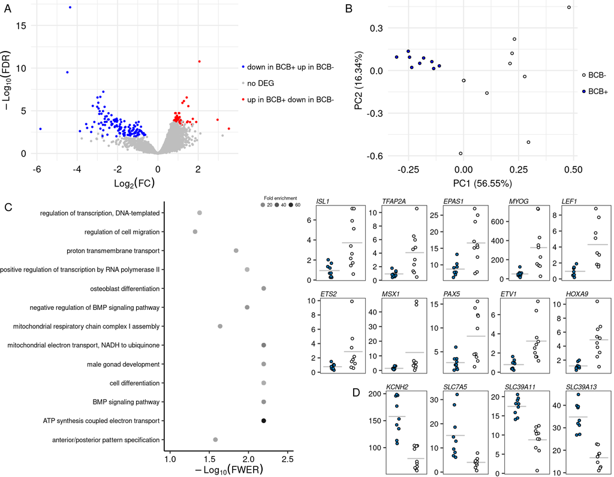

```r
plot_grid(plot_grid(volcano_plot_deg_cc,pca_plot_deg_cc, rel_widths=c(1,0.8), align="h", labels = c('A', 'B'),label_size = 12, label_fontface="plain"), plot_grid(GO_plot,plot_grid(plot_1,plot_grid(NULL,plot_2,rel_widths=c(0.25,1) , nrow=1, labels = c('', 'D'),label_size = 12, label_fontface="plain",hjust=2), nrow=2, rel_heights=c(1,0.5)), align="none",labels = c('C'),label_size = 12, label_fontface="plain"),nrow=2, rel_heights=c(1,1.4))
```

Figure 3. Differential transcript abundance in cumulus cells. (A) Depiction of the genes with significant differences in transcript abundance in cumulus cells surrounding oocytes categorized by BCB staining. (B) PCA plot of the 172 differentially expressed genes in cumulus cells collected from BCB positive or negative oocytes. (C) Biological processes categories enriched in 122 with greater transcript abundance in cumulus cells obtained from BCB negative oocytes relative to their counterparts. (D) Four genes with greater abundance in cumulus cells surrounding BCB positive oocytes and present in ‘transmembrane transport’.

#### Differential gene coexpression between oocytes and cumulus cells

Calculate the gene co-expression between oocytes and cumulus cells within each group.

```r
asinh_transf_CTF_normalized_oocyte_pos<-asinh_transf_CTF_normalized_oocyte[grep("pos",oocyte_group)]

asinh_transf_CTF_normalized_cumulus_pos<-asinh_transf_CTF_normalized_cumulus[grep("pos",cumulus_group)]

cor_oocyte_BCB_pos<-corAndPvalue(t(asinh_transf_CTF_normalized_oocyte_pos),t(asinh_transf_CTF_normalized_cumulus_pos), use = "pairwise.complete.obs",alternative="two.sided")

cor_oocyte_BCB_pos_value<-reshape2::melt(cor_oocyte_BCB_pos$cor)
cor_oocyte_BCB_pos_value<-as.data.table(cor_oocyte_BCB_pos_value)
cor_oocyte_BCB_pos_p_value<-melt(cor_oocyte_BCB_pos$p)
cor_oocyte_BCB_pos_p_value<-as.data.table(cor_oocyte_BCB_pos_p_value)
cor_oocyte_BCB_pos<-cbind(cor_oocyte_BCB_pos_value,cor_oocyte_BCB_pos_p_value)
rm(cor_oocyte_BCB_pos_p_value,cor_oocyte_BCB_pos_value)
cor_oocyte_BCB_pos<-cor_oocyte_BCB_pos[,c(1,2,3,6)]
cor_oocyte_BCB_pos<-cor_oocyte_BCB_pos[order(cor_oocyte_BCB_pos$value),]
#head(cor_oocyte_BCB_pos)
colnames(cor_oocyte_BCB_pos)<-c("gene_oocyte","gene_cumulus","correlation_pos","p_pos")

asinh_transf_CTF_normalized_oocyte_neg<-asinh_transf_CTF_normalized_oocyte[grep("neg",oocyte_group)]
asinh_transf_CTF_normalized_cumulus_neg<-asinh_transf_CTF_normalized_cumulus[grep("neg",cumulus_group)]
cor_oocyte_BCB_neg<-corAndPvalue(t(asinh_transf_CTF_normalized_oocyte_neg),t(asinh_transf_CTF_normalized_cumulus_neg), use = "pairwise.complete.obs",alternative="two.sided")

cor_oocyte_BCB_neg_value<-reshape2::melt(cor_oocyte_BCB_neg$cor)
cor_oocyte_BCB_neg_value<-as.data.table(cor_oocyte_BCB_neg_value)
cor_oocyte_BCB_neg_p_value<-melt(cor_oocyte_BCB_neg$p)
cor_oocyte_BCB_neg_p_value<-as.data.table(cor_oocyte_BCB_neg_p_value)
cor_oocyte_BCB_neg<-cbind(cor_oocyte_BCB_neg_value,cor_oocyte_BCB_neg_p_value)
rm(cor_oocyte_BCB_neg_p_value,cor_oocyte_BCB_neg_value)
cor_oocyte_BCB_neg<-cor_oocyte_BCB_neg[,c(1,2,3,6)]
cor_oocyte_BCB_neg<-cor_oocyte_BCB_neg[order(cor_oocyte_BCB_neg$value),]
#head(cor_oocyte_BCB_neg)
colnames(cor_oocyte_BCB_neg)<-c("gene_oocyte","gene_cumulus","correlation_neg","p_neg")

cor_oocyte_BCB_pos_neg<-merge(cor_oocyte_BCB_pos, cor_oocyte_BCB_neg, by=c("gene_oocyte","gene_cumulus"), all=TRUE)

cor_oocyte_BCB_pos_neg<-cor_oocyte_BCB_pos_neg[order(cor_oocyte_BCB_pos_neg$p_pos),]
```

Estimate the empirical false discovery rate for co-expression between BCB positive oocytes and cumulus cells.

```r
setwd("/mnt/storage/lab_folder/shared_R_codes/fernando/BCB_oocyte_cumulus/results/")
asinh_transf_CTF_normalized_oocyte_pos_big_matrix<- as.big.matrix(t(asinh_transf_CTF_normalized_oocyte_pos) , type = "double",
                    separated = FALSE,
                    backingfile = "asinh_transf_CTF_normalized_oocyte_pos.bin",
                    descriptorfile = "asinh_transf_CTF_normalized_oocyte_pos.desc",
                    share=TRUE)
# get a description of the matrix
mdesc_oocyte <- describe(asinh_transf_CTF_normalized_oocyte_pos_big_matrix)

asinh_transf_CTF_normalized_cumulus_pos_big_matrix <- as.big.matrix(t(asinh_transf_CTF_normalized_cumulus_pos), type = "double",
                      separated = FALSE,
                      backingfile = "asinh_transf_CTF_normalized_cumulus_pos.bin",
                      descriptorfile = "asinh_transf_CTF_normalized_cumulus_pos.desc",
                      share=TRUE)
# get a description of the matrix
mdesc_cumulus<- describe(asinh_transf_CTF_normalized_cumulus_pos_big_matrix)

permutation<-permutations(n = 9, r = 9, v = 1:9,repeats.allowed=FALSE)
permutation<-permutation[342880:362879,]

rand<-dim(permutation)[1]

sequence.correlation<-seq(0.90, 1, 0.01)

results <- filebacked.big.matrix(length(sequence.correlation),rand, type="double", init=0, separated=FALSE,
                                 backingfile="incidence_matrix.bin",
                                 descriptor="incidence_matrix.desc")
mdesc_result<- describe(results)

cl <- makeCluster(30)
registerDoParallel(cl)

results[,]<-foreach(i = sequence.correlation, .combine='rbind', .inorder=TRUE,  .packages=c("WGCNA","reshape","bigmemory"), .noexport=c("eet", "endo"), .verbose=FALSE) %:%

  foreach(j = 1:rand, .combine='cbind', .inorder=FALSE,.packages=c("WGCNA","reshape","bigmemory"), .noexport=c("asinh_transf_CTF_normalized_oocyte_pos_big_matrix", "asinh_transf_CTF_normalized_cumulus_pos_big_matrix"), .verbose=FALSE ) %dopar% {

    require(bigmemory)

    oocyte<- attach.big.matrix("asinh_transf_CTF_normalized_oocyte_pos.desc")
    cumulus<- attach.big.matrix("asinh_transf_CTF_normalized_cumulus_pos.desc")
    random<-WGCNA::cor(oocyte[permutation[j,],],  cumulus[,],  use = "pairwise.complete.obs", method="pearson")

    length(which(abs(random) > i))

  }

stopCluster(cl)

total.rand <- 20000 * 150076995

qvalue_BCB_pos<-data.frame(correlation = sequence.correlation, e.pvalue= (rowSums(results[,])+1)/(total.rand+1))

write.table(qvalue_BCB_pos, file = "qvalue_BCB_pos_2022_01_25.txt",quote = TRUE, sep = "\t",row.names = TRUE,col.names = TRUE)

system("rm asinh_transf_CTF_normalized_oocyte_pos.bin")
system("rm asinh_transf_CTF_normalized_oocyte_pos.desc")
system("rm asinh_transf_CTF_normalized_cumulus_pos.bin")
system("rm asinh_transf_CTF_normalized_cumulus_pos.desc")
system("rm incidence_matrix.bin")
system("rm incidence_matrix.desc")
```

Estimate the empirical false discovery rate for co-expression between BCB negative oocytes and cumulus cells.

```r
setwd("/mnt/storage/lab_folder/shared_R_codes/fernando/BCB_oocyte_cumulus/results/")
asinh_transf_CTF_normalized_oocyte_neg_big_matrix<- as.big.matrix(t(asinh_transf_CTF_normalized_oocyte_neg) , type = "double",
                    separated = FALSE,
                    backingfile = "asinh_transf_CTF_normalized_oocyte_neg.bin",
                    descriptorfile = "asinh_transf_CTF_normalized_oocyte_neg.desc",
                    share=TRUE)
# get a description of the matrix
mdesc_oocyte <- describe(asinh_transf_CTF_normalized_oocyte_neg_big_matrix)

asinh_transf_CTF_normalized_cumulus_neg_big_matrix <- as.big.matrix(t(asinh_transf_CTF_normalized_cumulus_neg), type = "double",
                      separated = FALSE,
                      backingfile = "asinh_transf_CTF_normalized_cumulus_neg.bin",
                      descriptorfile = "asinh_transf_CTF_normalized_cumulus_neg.desc",
                      share=TRUE)
# get a description of the matrix
mdesc_cumulus<- describe(asinh_transf_CTF_normalized_cumulus_neg_big_matrix)

permutation<-permutations(n = 10, r = 10, v = 1:10,repeats.allowed=FALSE)
permutation<-permutation[500320:520320,]

rand<-dim(permutation)[1]

sequence.correlation<-seq(0.90, 1, 0.01)

results <- filebacked.big.matrix(length(sequence.correlation),rand, type="double", init=0, separated=FALSE,
                                 backingfile="incidence_matrix.bin",
                                 descriptor="incidence_matrix.desc")
mdesc_result<- describe(results)

cl <- makeCluster(30)
registerDoParallel(cl)

results[,]<-foreach(i = sequence.correlation, .combine='rbind', .inorder=TRUE,  .packages=c("WGCNA","reshape","bigmemory"), .noexport=c("eet", "endo"), .verbose=FALSE) %:%

  foreach(j = 1:rand, .combine='cbind', .inorder=FALSE,.packages=c("WGCNA","reshape","bigmemory"), .noexport=c("asinh_transf_CTF_normalized_oocyte_neg_big_matrix", "asinh_transf_CTF_normalized_cumulus_neg_big_matrix"), .verbose=FALSE ) %dopar% {

    require(bigmemory)

    oocyte<- attach.big.matrix("asinh_transf_CTF_normalized_oocyte_neg.desc")
    cumulus<- attach.big.matrix("asinh_transf_CTF_normalized_cumulus_neg.desc")
    random<-WGCNA::cor(oocyte[permutation[j,],],  cumulus[,],  use = "pairwise.complete.obs", method="pearson")

    length(which(abs(random) > i))

  }

stopCluster(cl)

total.rand <- 20000 * 150076995

qvalue_BCB_neg<-data.frame(correlation = sequence.correlation, e.pvalue= (rowSums(results[,])+1)/(total.rand+1))

write.table(qvalue_BCB_neg, file = "qvalue_BCB_neg_2022_01_18.txt",quote = TRUE, sep = "\t",row.names = TRUE,col.names = TRUE)

system("rm asinh_transf_CTF_normalized_oocyte_neg.bin")
system("rm asinh_transf_CTF_normalized_oocyte_neg.desc")
system("rm asinh_transf_CTF_normalized_cumulus_neg.bin")
system("rm asinh_transf_CTF_normalized_cumulus_neg.desc")
system("rm incidence_matrix.bin")
system("rm incidence_matrix.desc")
```

##### Supplemental figure 4

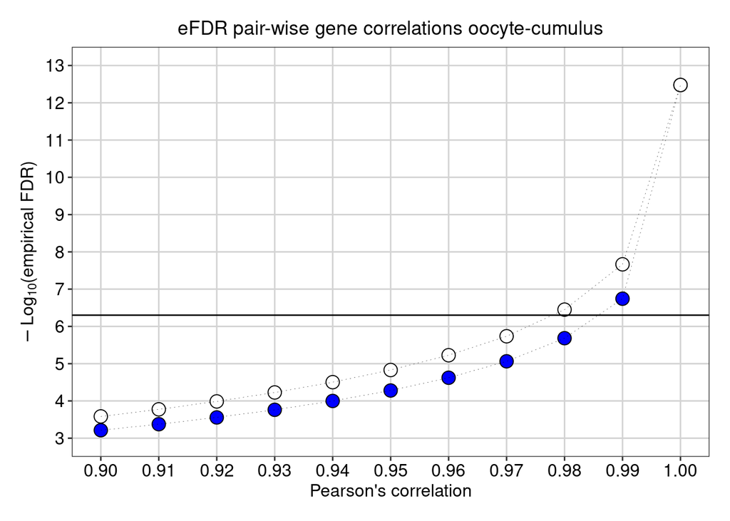

```r
qvalue_BCB_pos<-read.table("/mnt/storage/lab_folder/shared_R_codes/fernando/BCB_oocyte_cumulus/results/qvalue_BCB_pos_2022_01_19.txt",stringsAsFactors=FALSE, header =TRUE, sep="\t")

qvalue_BCB_neg<-read.table("/mnt/storage/lab_folder/shared_R_codes/fernando/BCB_oocyte_cumulus/results/qvalue_BCB_neg_2022_01_18.txt",stringsAsFactors=FALSE, header =TRUE, sep="\t")

qvalue_BCB_pos$log_pvalue <- -log((qvalue_BCB_pos$e.pvalue),10)
qvalue_BCB_neg$log_pvalue <- -log((qvalue_BCB_neg$e.pvalue),10)

font_size=12
ggplot()+
  geom_point(data=qvalue_BCB_pos, aes(x=correlation , y=log_pvalue), color="black", fill="blue", size=4, shape=21)+
  geom_line(data=qvalue_BCB_pos, aes(x=correlation , y=log_pvalue), color="black", size=0.1,linetype=3)+

  geom_point(data=qvalue_BCB_neg, aes(x=correlation , y=log_pvalue), color="black", fill="white", size=4, shape=21)+
  geom_line(data=qvalue_BCB_neg, aes(x=correlation , y=log_pvalue), color="black", size=0.1,linetype=3)+

  geom_hline(yintercept=-log((0.0000005),10))+

  scale_x_continuous(name="Pearson's correlation", limits = c(0.9, 1), breaks=seq(0.9,1, 0.01))+
  scale_y_continuous( limits = c(3, 13), breaks=seq(03,13, 1))+
  labs(y=expression(paste(-Log [10] ,"(empirical FDR)", sep="")))+
  ggtitle("eFDR pair-wise gene correlations oocyte-cumulus")+
  theme_bw()+
  theme(panel.grid= element_blank(),
        panel.background = element_blank(),
        panel.grid.minor = element_blank(),
        panel.grid.major = element_line(color="lightgray"),
        plot.background = element_blank(),
        axis.title=element_text(color="black", size=font_size),
        axis.text=element_text(color="black", size=font_size),
        panel.spacing = unit(c(0.4,0.4,0.4,0.4),"cm"),
        plot.margin = unit(c(0.5,0.5,0.5,0.5),"cm"),
        legend.position="none",
        plot.title = element_text(lineheight=.8, hjust=0.5))
```

Supplemental figure 4. Null distribution of empirical false discovery rate calculated for different values of correlation. Blue and white circles indicate the values calculated for BCB positive and negative cumulus oocyte complexes, respectively. Horizontal line crosses y-axis at -Log10(0.0000005).

##### Supplemental table 10

```r
cor_oocyte_BCB_pos_neg$oocyte_gene_symbol <- annotation.ensembl.symbol$external_gene_name[match(cor_oocyte_BCB_pos_neg$gene_oocyte,annotation.ensembl.symbol$ensembl_gene_id)]
cor_oocyte_BCB_pos_neg$cumulus_gene_symbol <- annotation.ensembl.symbol$external_gene_name[match(cor_oocyte_BCB_pos_neg$gene_cumulus,annotation.ensembl.symbol$ensembl_gene_id)]
cor_oocyte_BCB_pos_neg_099<-cor_oocyte_BCB_pos_neg[abs(correlation_pos)>0.99]
write.table(cor_oocyte_BCB_pos_neg_099, file= "/mnt/storage/lab_folder/shared_R_codes/fernando/BCB_oocyte_cumulus/results/cor_oocyte_BCB_pos_neg_099.txt", append = FALSE, quote = FALSE, sep = "\t" ,row.names = FALSE)
```

##### Supplemental table 11

```r
cor_oocyte_BCB_pos_neg_098<-cor_oocyte_BCB_pos_neg[abs(correlation_neg)>0.98]
write.table(cor_oocyte_BCB_pos_neg_098, file= "/mnt/storage/lab_folder/shared_R_codes/fernando/BCB_oocyte_cumulus/results/cor_oocyte_BCB_pos_neg_098.txt", append = FALSE, quote = FALSE, sep = "\t" ,row.names = FALSE)
```

```r
cor_oocyte_BCB_pos_neg$oocyte_gene_symbol <- annotation.ensembl.symbol$external_gene_name[match(cor_oocyte_BCB_pos_neg$gene_oocyte,annotation.ensembl.symbol$ensembl_gene_id)]
cor_oocyte_BCB_pos_neg$cumulus_gene_symbol <- annotation.ensembl.symbol$external_gene_name[match(cor_oocyte_BCB_pos_neg$gene_cumulus,annotation.ensembl.symbol$ensembl_gene_id)]
cor_oocyte_BCB_pos_neg_099<-cor_oocyte_BCB_pos_neg[abs(correlation_pos)>0.99]
write.table(cor_oocyte_BCB_pos_neg_099, file= "/mnt/storage/lab_folder/shared_R_codes/fernando/BCB_oocyte_cumulus/results/cor_oocyte_BCB_pos_neg_099.txt", append = FALSE, quote = FALSE, sep = "\t" ,row.names = FALSE)
cor_oocyte_BCB_pos_neg_098<-cor_oocyte_BCB_pos_neg[abs(correlation_neg)>0.98]
write.table(cor_oocyte_BCB_pos_neg_098, file= "/mnt/storage/lab_folder/shared_R_codes/fernando/BCB_oocyte_cumulus/results/cor_oocyte_BCB_pos_neg_098.txt", append = FALSE, quote = FALSE, sep = "\t" ,row.names = FALSE)
```

##### Supplemental table 12

GO oocyte genes

```r
gene.length<-read.delim("/mnt/storage/lab_folder/shared_R_codes/fernando/BCB_oocyte_cumulus/resources/2021_12_31_gene.length.txt.bz2", header=TRUE, sep= "\t",row.names=1, stringsAsFactors = FALSE)

all_genes<-data.frame( gene=oocyte_gene_annotation$Row.names, stringsAsFactors=FALSE )
rownames(all_genes)<-all_genes$gene
N_expressed_genes<-length(all_genes$gene)

gene.length<-gene.length[gene.length$ensembl_gene_id %in% all_genes$gene,]

annotation.genelength.biomart_vector<-gene.length$transcript_length
names(annotation.genelength.biomart_vector)<-gene.length$ensembl_gene_id

annotation.GO.BP.biomart<-annotation.GO.biomart[annotation.GO.biomart$namespace_1003=="biological_process", c(1,3)]
annotation.GO.BP.biomart<-annotation.GO.BP.biomart[annotation.GO.BP.biomart$ensembl_gene_id %in% rownames(all_genes),]
annotation.GO.MF.biomart<-annotation.GO.biomart[annotation.GO.biomart$namespace_1003=="molecular_function", c(1,3)]
annotation.GO.MF.biomart<-annotation.GO.MF.biomart[annotation.GO.MF.biomart$ensembl_gene_id %in% rownames(all_genes),]
```

```r
test.genes<-data.frame(a=unique(as.character(unique(cor_oocyte_BCB_pos[abs(correlation_pos) > 0.992 ]$gene_oocyte))), stringsAsFactors=FALSE)
all_genes_numeric<-as.integer(all_genes$gene %in%test.genes$a)
names(all_genes_numeric)<-all_genes$gene

N_sig_genes<-length(test.genes$a)

set.seed(87175)
pwf<-nullp(all_genes_numeric, bias.data=annotation.genelength.biomart_vector, plot.fit=FALSE )
GO_BP_Cats_oocyte_corr_cumulus<-goseq(pwf,gene2cat=annotation.GO.BP.biomart, method ="Sampling", repcnt = 5000, use_genes_without_cat=FALSE)
GO_BP_Cats_oocyte_corr_cumulus<-GO_BP_Cats_oocyte_corr_cumulus[GO_BP_Cats_oocyte_corr_cumulus$numDEInCat>3,]
GO_BP_Cats_oocyte_corr_cumulus$FWER<-p.adjust(GO_BP_Cats_oocyte_corr_cumulus$over_represented_pvalue, method ="holm")
GO_BP_Cats_oocyte_corr_cumulus<-GO_BP_Cats_oocyte_corr_cumulus[with(GO_BP_Cats_oocyte_corr_cumulus, order(FWER,over_represented_pvalue, -numDEInCat)), ]
#head(GO_BP_Cats_oocyte_corr_cumulus, n=20)

GO_BP_Cats_oocyte_corr_cumulus$fold_enrichment<-(GO_BP_Cats_oocyte_corr_cumulus$numDEInCat/N_sig_genes)/(GO_BP_Cats_oocyte_corr_cumulus$numInCat/N_expressed_genes)
annotation.GO.BP.biomart_testgenes<-annotation.GO.BP.biomart[annotation.GO.BP.biomart$ensembl_gene_id %in% test.genes$a, ]
GO_BP_Cats_oocyte_corr_cumulus<-merge(GO_BP_Cats_oocyte_corr_cumulus,annotation.GO.BP.biomart_testgenes, by.x="category", by.y="go_id", all.x=TRUE, all.y=FALSE)
GO_BP_Cats_oocyte_corr_cumulus<-merge(GO_BP_Cats_oocyte_corr_cumulus, annotation.ensembl.symbol, by.x="ensembl_gene_id", by.y="ensembl_gene_id", all=FALSE, all.x=TRUE, all.y=FALSE)
#GO_BP_Cats_oocyte_corr_cumulus<-GO_BP_Cats_oocyte_corr_cumulus[GO_BP_Cats_oocyte_corr_cumulus$FWER<0.1,]
GO_BP_Cats_oocyte_corr_cumulus<-GO_BP_Cats_oocyte_corr_cumulus[with(GO_BP_Cats_oocyte_corr_cumulus, order(FWER,term)), ]
GO_BP_Cats_oocyte_corr_cumulus$term<-factor(GO_BP_Cats_oocyte_corr_cumulus$term, levels=c(rev(unique(GO_BP_Cats_oocyte_corr_cumulus$term))))
#write.table(GO_BP_Cats_oocyte_corr_cumulus, file= "/mnt/storage/lab_folder/shared_R_codes/fernando/BCB_oocyte_cumulus/results/2022_02_22_GO_BP_Cats_subset_oocyte_corr_cumulus.txt", append = FALSE, quote = FALSE, sep = "\t" ,row.names = FALSE)
```

##### Supplemental table 13

GO cumulus genes

```r
gene.length<-read.delim("/mnt/storage/lab_folder/shared_R_codes/fernando/BCB_oocyte_cumulus/resources/2021_12_31_gene.length.txt.bz2", header=TRUE, sep= "\t",row.names=1, stringsAsFactors = FALSE)

all_genes<-data.frame( gene=cumulus_gene_annotation$Row.names, stringsAsFactors=FALSE )
rownames(all_genes)<-all_genes$gene
N_expressed_genes<-length(all_genes$gene)

gene.length<-gene.length[gene.length$ensembl_gene_id %in% all_genes$gene,]

annotation.genelength.biomart_vector<-gene.length$transcript_length
names(annotation.genelength.biomart_vector)<-gene.length$ensembl_gene_id

annotation.GO.BP.biomart<-annotation.GO.biomart[annotation.GO.biomart$namespace_1003=="biological_process", c(1,3)]
annotation.GO.BP.biomart<-annotation.GO.BP.biomart[annotation.GO.BP.biomart$ensembl_gene_id %in% rownames(all_genes),]
annotation.GO.MF.biomart<-annotation.GO.biomart[annotation.GO.biomart$namespace_1003=="molecular_function", c(1,3)]
annotation.GO.MF.biomart<-annotation.GO.MF.biomart[annotation.GO.MF.biomart$ensembl_gene_id %in% rownames(all_genes),]
```

```r
test.genes<-data.frame(a=as.character(unique(cor_oocyte_BCB_pos[abs(correlation_pos) > 0.992 ]$gene_cumulus)), stringsAsFactors=FALSE)
all_genes_numeric<-as.integer(all_genes$gene %in%test.genes$a)
names(all_genes_numeric)<-all_genes$gene

N_sig_genes<-length(test.genes$a)

set.seed(88972)
pwf<-nullp(all_genes_numeric, bias.data=annotation.genelength.biomart_vector, plot.fit=FALSE )
GO_BP_Cats_cumulus_corr_oocyte<-goseq(pwf,gene2cat=annotation.GO.BP.biomart, method ="Sampling", repcnt = 5000, use_genes_without_cat=FALSE)
#GO_BP_Cats_cumulus_corr_oocyte<-goseq(pwf,gene2cat=annotation.GO.BP.biomart, method ="Wallenius", use_genes_without_cat=FALSE)
GO_BP_Cats_cumulus_corr_oocyte<-GO_BP_Cats_cumulus_corr_oocyte[GO_BP_Cats_cumulus_corr_oocyte$numDEInCat>3,]
GO_BP_Cats_cumulus_corr_oocyte$FWER<-p.adjust(GO_BP_Cats_cumulus_corr_oocyte$over_represented_pvalue, method ="holm")
GO_BP_Cats_cumulus_corr_oocyte<-GO_BP_Cats_cumulus_corr_oocyte[with(GO_BP_Cats_cumulus_corr_oocyte, order(FWER,over_represented_pvalue, -numDEInCat)), ]
#head(GO_BP_Cats_cumulus_corr_oocyte, n=20)

GO_BP_Cats_cumulus_corr_oocyte$fold_enrichment<-(GO_BP_Cats_cumulus_corr_oocyte$numDEInCat/N_sig_genes)/(GO_BP_Cats_cumulus_corr_oocyte$numInCat/N_expressed_genes)
annotation.GO.BP.biomart_testgenes<-annotation.GO.BP.biomart[annotation.GO.BP.biomart$ensembl_gene_id %in% test.genes$a, ]
GO_BP_Cats_cumulus_corr_oocyte<-merge(GO_BP_Cats_cumulus_corr_oocyte,annotation.GO.BP.biomart_testgenes, by.x="category", by.y="go_id", all.x=TRUE, all.y=FALSE)
GO_BP_Cats_cumulus_corr_oocyte<-merge(GO_BP_Cats_cumulus_corr_oocyte, annotation.ensembl.symbol, by.x="ensembl_gene_id", by.y="ensembl_gene_id", all=FALSE, all.x=TRUE, all.y=FALSE)
GO_BP_Cats_cumulus_corr_oocyte<-GO_BP_Cats_cumulus_corr_oocyte[with(GO_BP_Cats_cumulus_corr_oocyte, order(FWER,term)), ]
#GO_BP_Cats_cumulus_corr_oocyte<-GO_BP_Cats_cumulus_corr_oocyte[GO_BP_Cats_cumulus_corr_oocyte$FWER <= 0.1,]
GO_BP_Cats_cumulus_corr_oocyte$term<-factor(GO_BP_Cats_cumulus_corr_oocyte$term, levels=c(rev(unique(GO_BP_Cats_cumulus_corr_oocyte$term))))
#write.table(GO_BP_Cats_cumulus_corr_oocyte, file= "/mnt/storage/lab_folder/shared_R_codes/fernando/BCB_oocyte_cumulus/results/2022_02_22_GO_BP_Cats_subset_cumulus_corr_oocyte.txt", append = FALSE, quote = FALSE, sep = "\t" ,row.names = FALSE)
```

##### Figure 4

```r
cor_oocyte_BCB_pos_neg_subset<- cor_oocyte_BCB_pos_neg[abs(correlation_pos)>0.99]

plot_coexpression_positive<-ggplot(aes(correlation_neg,correlation_pos), data=cor_oocyte_BCB_pos_neg_subset)+
geom_point(size=0.5)+
scale_y_continuous(name="co-expression \n cumulus oocyte BCB+")+
scale_x_continuous(name="cumulus oocyte BCB-")+
theme_classic(base_size=12)+
theme(
axis.title=element_text(color="black", size=10),
axis.text=element_text(color="black",  size=10),
)

cor_oocyte_BCB_pos_neg_subset$oocyte_gene_symbol <- annotation.ensembl.symbol$external_gene_name[match(cor_oocyte_BCB_pos_neg_subset$gene_oocyte,annotation.ensembl.symbol$ensembl_gene_id)]
cor_oocyte_BCB_pos_neg_subset$cumulus_gene_symbol <- annotation.ensembl.symbol$external_gene_name[match(cor_oocyte_BCB_pos_neg_subset$gene_cumulus,annotation.ensembl.symbol$ensembl_gene_id)]

cor_oocyte_BCB_pos_neg_subset$angle<-NA
cor_oocyte_BCB_pos_neg_subset$r.squared<-NA
cor_oocyte_BCB_pos_neg_subset$rmse<-NA
cor_oocyte_BCB_pos_neg_subset$fstatistic<-NA

for (i in seq(dim(cor_oocyte_BCB_pos_neg_subset)[1]))
{
gene_oocyte<-as.character(cor_oocyte_BCB_pos_neg_subset$gene_oocyte)[i]
gene_cumulus<-as.character(cor_oocyte_BCB_pos_neg_subset$gene_cumulus)[i]

gene_symbol_oocyte<-as.character(cor_oocyte_BCB_pos_neg_subset$oocyte_gene_symbol)[i]
gene_symbol_cumulus<-as.character(cor_oocyte_BCB_pos_neg_subset$cumulus_gene_symbol)[i]

expression_oocyte<-data.frame(expression_oocyte=t(oocyte_tpm_filtred[rownames(oocyte_tpm_filtred)==gene_oocyte,grep("pos",oocyte_group)])[,1])
expression_cumulus<-data.frame( expression_cumulus=t(cumulus_tpm_filtred[rownames(cumulus_tpm_filtred)==gene_cumulus,grep("pos",cumulus_group)])[,1])

model_oocyte_cc<-lm(expression_oocyte$expression_oocyte ~ expression_cumulus$expression_cumulus)

cor_oocyte_BCB_pos_neg_subset$angle[i]<-unname(atan(coef(model_oocyte_cc)[2]) * (180 / pi))
cor_oocyte_BCB_pos_neg_subset$r.squared[i]<-summary(model_oocyte_cc)$adj.r.squared
cor_oocyte_BCB_pos_neg_subset$rmse[i]<-sqrt(mean(model_oocyte_cc$residuals^2))
cor_oocyte_BCB_pos_neg_subset$fstatistic[i]<-unname(summary(model_oocyte_cc)$fstatistic[1])
}

cor_oocyte_BCB_pos_neg_subset<-cor_oocyte_BCB_pos_neg_subset[!(cor_oocyte_BCB_pos_neg_subset$oocyte_gene_symbol=="") & !(cor_oocyte_BCB_pos_neg_subset$cumulus_gene_symbol=="" )]
cor_oocyte_BCB_pos_neg_subset<-cor_oocyte_BCB_pos_neg_subset[cor_oocyte_BCB_pos_neg_subset$angle > 35 & cor_oocyte_BCB_pos_neg_subset$angle < 60,]
cor_oocyte_BCB_pos_neg_subset<-cor_oocyte_BCB_pos_neg_subset[order(cor_oocyte_BCB_pos_neg_subset$rmse , decreasing = FALSE),]

dataframegraph<-data.frame()

for (i in c(1:4)){

gene_oocyte<-as.character(cor_oocyte_BCB_pos_neg_subset$gene_oocyte)[i]
gene_cumulus<-as.character(cor_oocyte_BCB_pos_neg_subset$gene_cumulus)[i]

gene_symbol_oocyte<-as.character(cor_oocyte_BCB_pos_neg_subset$oocyte_gene_symbol)[i]
gene_symbol_cumulus<-as.character(cor_oocyte_BCB_pos_neg_subset$cumulus_gene_symbol)[i]

expression_oocyte<-data.frame(expression_oocyte=t(oocyte_tpm_filtred[rownames(oocyte_tpm_filtred)==gene_oocyte,grep("pos",oocyte_group)])[,1])
expression_cumulus<-data.frame( expression_cumulus=t(cumulus_tpm_filtred[rownames(cumulus_tpm_filtred)==gene_cumulus,grep("pos",cumulus_group)])[,1])

graph<-i

dataframegraph<-rbind(data.frame(gene_oocyte,gene_cumulus,gene_symbol_oocyte,gene_symbol_cumulus,expression_oocyte,expression_cumulus,graph),dataframegraph)
}

plots<-list()

for (i in c(1:4)){

plots[[i]]<- ggplot(dataframegraph[dataframegraph$graph==i,], aes(x=expression_oocyte, y= expression_cumulus ))+
geom_smooth(method='lm', formula= y~x, size=0.5)+
geom_point( size=0.5)+
scale_x_continuous(name=dataframegraph[dataframegraph$graph==i,]$gene_symbol_oocyte[1],breaks = function(x) unique(floor(pretty(seq(0, (max(x) + 1) * 1.1)))))+
scale_y_continuous(name=dataframegraph[dataframegraph$graph==i,]$gene_symbol_cumulus[1], breaks = function(x) unique(floor(pretty(seq(0, (max(x) + 1) * 1.1)))))+
theme_classic()+
theme(
axis.title=element_text(face="italic", size=7),
axis.text=element_text( color="black",size=7),
)
}

top.grob <- textGrob("BCB +", gp=gpar(fontface="plain", col="black", fontsize=10))

plot_correlation_bcb_pos<-plot_grid(  grid.arrange(arrangeGrob(plot_grid(plotlist=plots, nrow=1), top = top.grob)))

dataframegraph<-data.frame()

for (i in c(1:4)){

gene_oocyte<-as.character(cor_oocyte_BCB_pos_neg_subset$gene_oocyte)[i]
gene_cumulus<-as.character(cor_oocyte_BCB_pos_neg_subset$gene_cumulus)[i]

gene_symbol_oocyte<-as.character(cor_oocyte_BCB_pos_neg_subset$oocyte_gene_symbol)[i]
gene_symbol_cumulus<-as.character(cor_oocyte_BCB_pos_neg_subset$cumulus_gene_symbol)[i]

expression_oocyte<-data.frame(expression_oocyte=t(oocyte_tpm_filtred[rownames(oocyte_tpm_filtred)==gene_oocyte,grep("neg",oocyte_group)])[,1])
expression_cumulus<-data.frame( expression_cumulus=t(cumulus_tpm_filtred[rownames(cumulus_tpm_filtred)==gene_cumulus,grep("neg",cumulus_group)])[,1])

graph<-i

dataframegraph<-rbind(data.frame(gene_oocyte,gene_cumulus,gene_symbol_oocyte,gene_symbol_cumulus,expression_oocyte,expression_cumulus,graph),dataframegraph)
}

plots<-list()

for (i in c(1:4)){

plots[[i]]<- ggplot(dataframegraph[dataframegraph$graph==i,], aes(x=expression_oocyte, y= expression_cumulus ))+
geom_smooth(method='lm', formula= y~x, size=0.5)+
geom_point( size=0.5)+
scale_x_continuous(name=dataframegraph[dataframegraph$graph==i,]$gene_symbol_oocyte[1],breaks = function(x) unique(floor(pretty(seq(0, (max(x) + 1) * 1.1)))))+
scale_y_continuous(name=dataframegraph[dataframegraph$graph==i,]$gene_symbol_cumulus[1], breaks = function(x) unique(floor(pretty(seq(0, (max(x) + 1) * 1.1)))))+
theme_classic()+
theme(
axis.title=element_text(face="italic", size=7),
axis.text=element_text( color="black",size=7),
)
}

top.grob <- textGrob("BCB -", gp=gpar(fontface="plain", col="black", fontsize=10))

plot_bcb_neg<-plot_grid(  grid.arrange(arrangeGrob(plot_grid(plotlist=plots, nrow=1), top = top.grob)))

y.grob <- textGrob("Cumulus cells", gp=gpar(fontface="plain", col="black", fontsize=10), rot=90)
```

```r
x.grob <- textGrob("Oocytes", gp=gpar(fontface="plain", col="black", fontsize=10))

plot_bcb_pos_scatter_examples<-grid.arrange(arrangeGrob(plot_grid(plot_correlation_bcb_pos,plot_bcb_neg, nrow=2), left = y.grob,bottom = x.grob))

plot_a<-cowplot::plot_grid(plot_coexpression_positive,
                          plot_bcb_pos_scatter_examples, nrow=2, labels = c("A"), label_fontface = "plain", label_size = 12, rel_heights=c(0.8,1))



cor_oocyte_BCB_pos_neg_subset<- cor_oocyte_BCB_pos_neg[abs(correlation_neg)>0.98]

plot_coexpression_negative<-ggplot(aes(x=correlation_pos, y=correlation_neg), data=cor_oocyte_BCB_pos_neg_subset)+
geom_point(size=0.5)+
scale_y_continuous(name="co-expression \n cumulus oocyte BCB-")+
scale_x_continuous(name="cumulus oocyte BCB+")+
theme_classic(base_size=12)+
theme(
axis.title=element_text(color="black", size=10),
axis.text=element_text(color="black",  size=10),
)

cor_oocyte_BCB_pos_neg_subset$oocyte_gene_symbol <- annotation.ensembl.symbol$external_gene_name[match(cor_oocyte_BCB_pos_neg_subset$gene_oocyte,annotation.ensembl.symbol$ensembl_gene_id)]
cor_oocyte_BCB_pos_neg_subset$cumulus_gene_symbol <- annotation.ensembl.symbol$external_gene_name[match(cor_oocyte_BCB_pos_neg_subset$gene_cumulus,annotation.ensembl.symbol$ensembl_gene_id)]

cor_oocyte_BCB_pos_neg_subset$angle<-NA
cor_oocyte_BCB_pos_neg_subset$r.squared<-NA
cor_oocyte_BCB_pos_neg_subset$rmse<-NA
cor_oocyte_BCB_pos_neg_subset$fstatistic<-NA

for (i in seq(dim(cor_oocyte_BCB_pos_neg_subset)[1]))
{
gene_oocyte<-as.character(cor_oocyte_BCB_pos_neg_subset$gene_oocyte)[i]
gene_cumulus<-as.character(cor_oocyte_BCB_pos_neg_subset$gene_cumulus)[i]

gene_symbol_oocyte<-as.character(cor_oocyte_BCB_pos_neg_subset$oocyte_gene_symbol)[i]
gene_symbol_cumulus<-as.character(cor_oocyte_BCB_pos_neg_subset$cumulus_gene_symbol)[i]

expression_oocyte<-data.frame(expression_oocyte=t(oocyte_tpm_filtred[rownames(oocyte_tpm_filtred)==gene_oocyte,grep("neg",oocyte_group)])[,1])
expression_cumulus<-data.frame( expression_cumulus=t(cumulus_tpm_filtred[rownames(cumulus_tpm_filtred)==gene_cumulus,grep("neg",cumulus_group)])[,1])

model_oocyte_cc<-lm(expression_oocyte$expression_oocyte ~ expression_cumulus$expression_cumulus)

cor_oocyte_BCB_pos_neg_subset$angle[i]<-unname(atan(coef(model_oocyte_cc)[2]) * (180 / pi))
cor_oocyte_BCB_pos_neg_subset$r.squared[i]<-summary(model_oocyte_cc)$adj.r.squared
cor_oocyte_BCB_pos_neg_subset$rmse[i]<-sqrt(mean(model_oocyte_cc$residuals^2))
cor_oocyte_BCB_pos_neg_subset$fstatistic[i]<-unname(summary(model_oocyte_cc)$fstatistic[1])
}
cor_oocyte_BCB_pos_neg_subset<-cor_oocyte_BCB_pos_neg_subset[!(cor_oocyte_BCB_pos_neg_subset$oocyte_gene_symbol=="") & !(cor_oocyte_BCB_pos_neg_subset$cumulus_gene_symbol=="" )]
cor_oocyte_BCB_pos_neg_subset<-cor_oocyte_BCB_pos_neg_subset[cor_oocyte_BCB_pos_neg_subset$angle > 35 & cor_oocyte_BCB_pos_neg_subset$angle < 60,]
cor_oocyte_BCB_pos_neg_subset<-cor_oocyte_BCB_pos_neg_subset[order(cor_oocyte_BCB_pos_neg_subset$rmse , decreasing = FALSE),]

dataframegraph<-data.frame()

for (i in c(1:4)){

gene_oocyte<-as.character(cor_oocyte_BCB_pos_neg_subset$gene_oocyte)[i]
gene_cumulus<-as.character(cor_oocyte_BCB_pos_neg_subset$gene_cumulus)[i]

gene_symbol_oocyte<-as.character(cor_oocyte_BCB_pos_neg_subset$oocyte_gene_symbol)[i]
gene_symbol_cumulus<-as.character(cor_oocyte_BCB_pos_neg_subset$cumulus_gene_symbol)[i]

expression_oocyte<-data.frame(expression_oocyte=t(oocyte_tpm_filtred[rownames(oocyte_tpm_filtred)==gene_oocyte,grep("neg",oocyte_group)])[,1])
expression_cumulus<-data.frame( expression_cumulus=t(cumulus_tpm_filtred[rownames(cumulus_tpm_filtred)==gene_cumulus,grep("neg",cumulus_group)])[,1])

graph<-i

dataframegraph<-rbind(data.frame(gene_oocyte,gene_cumulus,gene_symbol_oocyte,gene_symbol_cumulus,expression_oocyte,expression_cumulus,graph),dataframegraph)
}

plots<-list()

for (i in c(1:4)){

plots[[i]]<- ggplot(dataframegraph[dataframegraph$graph==i,], aes(x=expression_oocyte, y= expression_cumulus ))+
geom_smooth(method='lm', formula= y~x, size=0.5)+
geom_point( size=0.5)+
scale_x_continuous(name=dataframegraph[dataframegraph$graph==i,]$gene_symbol_oocyte[1],breaks = function(x) unique(floor(pretty(seq(0, (max(x) + 1) * 1.1)))))+
scale_y_continuous(name=dataframegraph[dataframegraph$graph==i,]$gene_symbol_cumulus[1], breaks = function(x) unique(floor(pretty(seq(0, (max(x) + 1) * 1.1)))))+
theme_classic()+
theme(
axis.title=element_text(face="italic", size=7),
axis.text=element_text( color="black",size=7),
)
}

top.grob <- textGrob("BCB -", gp=gpar(fontface="plain", col="black", fontsize=10))

plot_correlation_bcb_neg<-plot_grid(  grid.arrange(arrangeGrob(plot_grid(plotlist=plots, nrow=1), top = top.grob)))

dataframegraph<-data.frame()

for (i in c(1:4)){

gene_oocyte<-as.character(cor_oocyte_BCB_pos_neg_subset$gene_oocyte)[i]
gene_cumulus<-as.character(cor_oocyte_BCB_pos_neg_subset$gene_cumulus)[i]

gene_symbol_oocyte<-as.character(cor_oocyte_BCB_pos_neg_subset$oocyte_gene_symbol)[i]
gene_symbol_cumulus<-as.character(cor_oocyte_BCB_pos_neg_subset$cumulus_gene_symbol)[i]

expression_oocyte<-data.frame(expression_oocyte=t(oocyte_tpm_filtred[rownames(oocyte_tpm_filtred)==gene_oocyte,grep("pos",oocyte_group)])[,1])
expression_cumulus<-data.frame( expression_cumulus=t(cumulus_tpm_filtred[rownames(cumulus_tpm_filtred)==gene_cumulus,grep("pos",cumulus_group)])[,1])

graph<-i

dataframegraph<-rbind(data.frame(gene_oocyte,gene_cumulus,gene_symbol_oocyte,gene_symbol_cumulus,expression_oocyte,expression_cumulus,graph),dataframegraph)
}

plots<-list()

for (i in c(1:4)){

plots[[i]]<- ggplot(dataframegraph[dataframegraph$graph==i,], aes(x=expression_oocyte, y= expression_cumulus ))+
geom_smooth(method='lm', formula= y~x, size=0.5)+
geom_point( size=0.5)+
scale_x_continuous(name=dataframegraph[dataframegraph$graph==i,]$gene_symbol_oocyte[1],breaks = function(x) unique(floor(pretty(seq(0, (max(x) + 1) * 1.1)))))+
scale_y_continuous(name=dataframegraph[dataframegraph$graph==i,]$gene_symbol_cumulus[1], breaks = function(x) unique(floor(pretty(seq(0, (max(x) + 1) * 1.1)))))+
theme_classic()+
theme(
axis.title=element_text(face="italic", size=7),
axis.text=element_text( color="black",size=7),
)
}
```

```r
top.grob <- textGrob("BCB +", gp=gpar(fontface="plain", col="black", fontsize=10))

plot_bcb_pos<-plot_grid(  grid.arrange(arrangeGrob(plot_grid(plotlist=plots, nrow=1), top = top.grob)))

y.grob <- textGrob("Cumulus cells", gp=gpar(fontface="plain", col="black", fontsize=10), rot=90)

x.grob <- textGrob("Oocytes", gp=gpar(fontface="plain", col="black", fontsize=10))


plot_bcb_neg_scatter_examples<-cowplot::plot_grid(grid.arrange(arrangeGrob(plot_grid(plot_correlation_bcb_neg,plot_bcb_pos, nrow=2), left = y.grob,bottom = x.grob)))

plot_b<-cowplot::plot_grid(plot_coexpression_negative,
                            plot_bcb_neg_scatter_examples,
                             nrow=2, labels = c("B"), label_fontface = "plain", label_size = 12, rel_heights = c(0.8,1))


treshold<-0.992

asinh_transf_CTF_normalized_oocyte_pos_subset<-asinh_transf_CTF_normalized_oocyte_pos[rownames(asinh_transf_CTF_normalized_oocyte_pos) %in%  as.character(unique(cor_oocyte_BCB_pos[abs(correlation_pos) >= treshold ]$gene_oocyte)), ]
asinh_transf_CTF_normalized_cumulus_pos_subset<-asinh_transf_CTF_normalized_cumulus_pos[rownames(asinh_transf_CTF_normalized_cumulus_pos) %in%  as.character(unique(cor_oocyte_BCB_pos[abs(correlation_pos) >= treshold ]$gene_cumulus)), ]
#colnames(asinh_transf_CTF_normalized_oocyte_pos_subset)
colnames(asinh_transf_CTF_normalized_oocyte_pos_subset)<-c("coc17", "coc19", "coc24" ,"coc69", "coc70", "coc71" ,"coc72", "coc73", "coc74")
#colnames(asinh_transf_CTF_normalized_cumulus_pos_subset)
colnames(asinh_transf_CTF_normalized_cumulus_pos_subset)<-c("coc17", "coc19", "coc24" ,"coc69", "coc70", "coc71" ,"coc72", "coc73", "coc74")

source("/mnt/storage/lab_folder/shared_R_codes/fernando/BCB_oocyte_cumulus/resources/functions_plot_tanglegram.R")

hc1     <- t(asinh_transf_CTF_normalized_oocyte_pos_subset)  %>% dist %>%  flashClust(method = "average")
hc2     <- t(asinh_transf_CTF_normalized_cumulus_pos_subset) %>% dist %>%  flashClust(method = "average")
hcdata1 <- dendro_data_k(hc1,1)
hcdata2 <- dendro_data_k(hc2,1)

p1 <- plot_ggdendro(hcdata1,
                    direction   = "lr",
                    scale.color = "black",
                    branch.size = 0.5,
                    expand.y    = 1,
                    label.size  = 4)  +
                    theme(plot.background=element_blank(),
                    panel.background=element_blank(),
                    axis.text=element_blank(),
                    axis.title=element_blank(),
                    axis.ticks=element_blank())

p2 <- plot_ggdendro(hcdata2,
                    direction   = "rl",
                    scale.color = "black",
                    branch.size = 0.5,
                    expand.y    = 1,
                    label.size  = 4)+
                    theme(plot.background=element_blank(),
                    panel.background=element_blank(),
                    axis.text=element_blank(),
                    axis.title=element_blank(),
                    axis.ticks=element_blank())

idx <- data.frame(y1 = 1:nrow(hcdata1$labels),
                  y2 = match(hcdata1$labels$label, hcdata2$labels$label))

p3 <- ggplot() +
  geom_segment(data     = idx,
               aes(x    = 0,
                   y    = y1,
                   xend = 1,
                   yend = y2),
               color    = c("blue", "blue", "blue","blue", "gray","gray","blue", "blue", "blue")) +
  theme_void()



plot_dendrogram_BCB_pos<-grid.arrange(arrangeGrob(p1, p3, p2, ncol = 3, widths = c(2, 0.3, 2),
left = textGrob("oocyte", gp=gpar(fontface="plain", col="black", fontsize=font_size), rot=90),
right = textGrob("cumulus", gp=gpar(fontface="plain", col="black", fontsize=font_size), rot=90),
top  = textGrob("BCB positive", gp=gpar(fontface="plain", col="black", fontsize=font_size))))
```

```r
cor_oocyte_BCB_pos_subset<-cor_oocyte_BCB_pos[abs(correlation_pos) >= 0.992 ]

cor_oocyte_BCB_pos_subset$oocyte_symbol<- annotation.ensembl.symbol$external_gene_name[match(cor_oocyte_BCB_pos_subset$gene_oocyte,annotation.ensembl.symbol$ensembl_gene_id)]
cor_oocyte_BCB_pos_subset$cumulus_symbol<- annotation.ensembl.symbol$external_gene_name[match(cor_oocyte_BCB_pos_subset$gene_cumulus,annotation.ensembl.symbol$ensembl_gene_id)]

cor_oocyte_BCB_pos_subset<-cor_oocyte_BCB_pos_subset[!(cor_oocyte_BCB_pos_subset$oocyte_symbol =="") &  !(cor_oocyte_BCB_pos_subset$cumulus_symbol ==""),]

#write.table(cor_oocyte_BCB_pos_subset, file= "/mnt/storage/lab_folder/shared_R_codes/fernando/BCB_oocyte_cumulus/results/2022_02_24_cor_oocyte_BCB_pos_subset.txt", append = FALSE, quote = FALSE, sep = "\t" ,row.names = FALSE)

links<-data.frame(source=cor_oocyte_BCB_pos_subset$oocyte_symbol, target=cor_oocyte_BCB_pos_subset$cumulus_symbol)

links<-links[complete.cases(links),]
links<-links[!duplicated(links),]

nodes <- data.frame(name = unique(c(links$source, links$target)))
nodes$target<-nodes$name %in%cor_oocyte_BCB_pos_subset$cumulus_symbol
nodes$source<-nodes$name %in%cor_oocyte_BCB_pos_subset$oocyte_symbol


links$source <- match(links$source, nodes$name) - 1
links$target <- match(links$target, nodes$name) - 1
links$value <- 1

sn<-sankeyNetwork(Links = links, Nodes = nodes, Source = 'source',
                    Target = 'target',Value = 'value', NodeID = 'name',sinksRight=FALSE,  nodePadding = 8, fontSize = 10, margin=1500)
sn$x$nodes$target <- nodes$target
sn$x$nodes$source <- nodes$source

sn <- onRender(sn,
  '
  function(el) {
    d3.select(el)
      .selectAll(".node text")
      .filter(d => d.source)
      .attr("x", -3)
      .attr("text-anchor", "end");
  }
  '
)

setwd("/mnt/storage/lab_folder/shared_R_codes/fernando/BCB_oocyte_cumulus/results/")
saveNetwork(sn, "sn.html")
```

```r
y.grob <- textGrob("Genes expressed in oocytes", gp=gpar(fontface="plain", col="black", fontsize=10), rot=90)
x.grob <- textGrob("Genes expressed in cumulus cells", gp=gpar(fontface="plain", col="black", fontsize=10),rot=90)
fig <- ggdraw() + draw_image(magick::image_read_pdf("/mnt/storage/lab_folder/shared_R_codes/fernando/BCB_oocyte_cumulus/results/sankeyNetwork.pdf", density = 600))
```

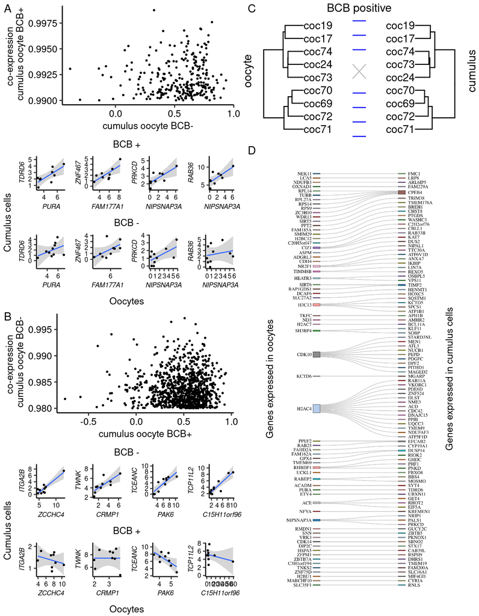

```r
cowplot::plot_grid(
cowplot::plot_grid(plot_a,plot_b,ncol=1),
cowplot::plot_grid( plot_dendrogram_BCB_pos,
  cowplot::plot_grid(NULL, y.grob, cowplot::plot_grid(fig) ,x.grob, NULL, nrow=1, rel_widths=c(0.1,0.2,1,0.2,0.1)),
  rel_heights=c(0.3,1),rel_widths=c(0.2,1),ncol=1, labels = c("C", "D"),hjust=-1 ,  label_fontface = "plain", label_size = 12)
, ncol=2
)
```

Figure 4. Differential co-expression in oocytes and surrounding cumulus cells classified by BCB staining. (A) Genes significantly co-expressed in BCB positive oocytes and surrounding cumulus cells, comparatively to complex-oocyte complexes obtained from BCB negative oocytes. (B) Genes significantly co-expressed in BCB negative oocytes and surrounding cumulus cells, comparatively to cumulus-oocyte complexes obtained from BCB positive oocytes. (C) Independent clustering of oocytes and cumulus cells using 75 and 108 genes, respectively, co-expressing at r≥ 0.992. (D) Connectivity of the genes expressed in oocytes and surrounding cumulus cells co-expressing at r≥ 0.992. Only genes annotated with a symbol are depicted on panel D.